# report-for-primatologypaper

João Coelho

March 26, 2018

## Vertebrate consumption by wild bearded capuchin monkeys (*Sapajus libidinosus*) living in a Brazilian semiarid habitat

#### Short report from a data analysis in R

Let’s pull all data

```r
SSdata <- read.csv2("/Users/del/ACADEMY/WIP/CVP/data2SS.csv") # Reading dataset with Scan Sampling raw data
AOdata <- read.csv2("/Users/del/ACADEMY/WIP/CVP/AOdata.csv") # Reading dataset with All Occurences raw data
ALLdata <- read.csv("/Users/del/ACADEMY/WIP/CVP/allSummary.csv", sep=";") # Reading summary dataset
```

## Data cleaning

Some data cleaning in order to improve readability

```r
SSdata$Group <- as.factor(SSdata$Group)
AOdata$Group <- as.factor(AOdata$Group)
levels(SSdata$Group) <- c('ZA', 'CH')
levels(AOdata$Group) <- c('ZA', 'CH')
SSdata$Sex <- as.factor(SSdata$Sex)
levels(SSdata$Sex) <- c('Male', 'Female')
SSdata$Age <- as.factor(SSdata$Age)
levels(SSdata$Age) <- c('Adult', 'Juvenile', 'Infant')
SSdata$Season <- as.factor(SSdata$Season)
levels(SSdata$Season) <- c('Rain', 'Dry')
SSdata_without_infants <- SSdata[SSdata$Age != 'Infant',] # separate dataset without infants
SSdata_without_infants$Age <- droplevels(SSdata_without_infants$Age)
```

## Exercises

**Correct and fill**: *A total of 474 events of vertebrate consumption were observed between 2006 and 2010 (274 recorded by scan sampling and 200 recorded by all occurrences), CH group accounted for XX events, and ZA group for XX events.*

```r
sum(SSdata$Scan.consumed.month) + sum(AOdata$TotalEpisodes)
```

```
## [1] 446
```

```r
sum(SSdata$Scan.consumed.month)
```

```
## [1] 281
```

```r
sum(AOdata$TotalEpisodes)
```

```
## [1] 165
```

```r
sum(AOdata$TotalEpisodes[AOdata$Group == 'CH']) + sum(SSdata$Scan.consumed.month[SSdata$Group == 'CH'])
```

```
## [1] 212
```

```r
sum(AOdata$TotalEpisodes[AOdata$Group == 'ZA']) + sum(SSdata$Scan.consumed.month[SSdata$Group == 'ZA'])
```

```
## [1] 234
```

A total of **446** events of vertebrate consumption were observed between 2006 and 2010 (**281** recorded by scan sampling and **165** recorded by all occurrences), CH group accounted for **212** events, and ZA group for **234** events.

**Correct and fill**: *Of 213 episodes recorded by all occurrences for both groups, 81.2% (N=XX) were episodes in which only one individual was seen consuming the prey, whereas XX% (N=XX) were episodes in which two or more monkeys were seen consuming the same prey;*

```r
sum(AOdata$IndEpisodes)/sum(AOdata$TotalEpisodes)*100 # percent
```

```
## [1] 81.21212
```

```r
sum(AOdata$IndEpisodes) # n
```

```
## [1] 134
```

```r
sum(AOdata$MultipleIndEpisodes)/sum(AOdata$TotalEpisodes)*100 # percent
```

```
## [1] 18.78788
```

```r
sum(AOdata$MultipleIndEpisodes) # n
```

```
## [1] 31
```

Of **165** episodes recorded by all occurrences for both groups, **81.21%** (N=**134**) were episodes in which only one individual was seen consuming the prey, whereas **18.79%** (N=**31**) were episodes in which two or more monkeys were seen consuming the same prey;

**Correct and fill**: *The major prey types were reptiles (n=131: lizards, geckos, snakes, iguanas), mammals (n=95: primarily rodents, but also opossums, a bat) and birds (n=34: especially nestlings and eggs).*

```r
sum(c(SSdata$Lizards, SSdata$Serpents)) # reptiles
```

```
## [1] 136
```

```r
sum(c(SSdata$Rodents, SSdata$MarsupialsMammals, SSdata$Chiroptera)) # mammals
```

```
## [1] 97
```

```r
sum(SSdata$Aves) # birds
```

```
## [1] 34
```

The major prey types were reptiles (n=**136**: lizards, geckos, snakes, iguanas), mammals (n=**97**: primarily rodents, but also opossums, a bat) and birds (n=34: especially nestlings and eggs).

**Calculate percentages for Table 2**

Table 2 in the Word file has many errors. Here I recalculate all values for paper-corrections.

```r
str(SSdata[,9:15])
```

```
## 'data.frame':    1135 obs. of  7 variables:
##  $ Lizards          : int  0 0 0 1 4 0 0 0 0 2 ...
##  $ Serpents         : int  0 0 0 0 0 0 0 0 0 0 ...
##  $ Rodents          : int  0 0 0 0 0 0 0 0 0 0 ...
##  $ MarsupialsMammals: int  0 0 0 0 0 0 0 0 0 0 ...
##  $ Chiroptera       : int  0 0 0 0 0 0 0 0 0 0 ...
##  $ Aves             : int  0 0 0 0 0 0 0 0 0 0 ...
##  $ Undertermined    : int  0 0 0 0 1 0 0 0 0 0 ...
```

```r
sum(SSdata$Lizards)/sum(SSdata[,9:15])*100
```

```
## [1] 43.77224
```

```r
sum(SSdata$Serpents)/sum(SSdata[,9:15])*100
```

```
## [1] 4.626335
```

```r
sum(SSdata$Rodents)/sum(SSdata[,9:15])*100
```

```
## [1] 28.46975
```

```r
sum(SSdata$MarsupialsMammals)/sum(SSdata[,9:15])*100
```

```
## [1] 5.338078
```

```r
sum(SSdata$Chiroptera)/sum(SSdata[,9:15])*100
```

```
## [1] 0.7117438
```

```r
sum(SSdata$Aves)/sum(SSdata[,9:15])*100
```

```
## [1] 12.09964
```

```r
sum(SSdata$Undertermined)/sum(SSdata[,9:15])*100
```

```
## [1] 4.982206
```

```r
sum(SSdata[,9:15])
```

```
## [1] 281
```

## Visualization

#### Differences of vertebrate consumption (from SS data) amongst groups

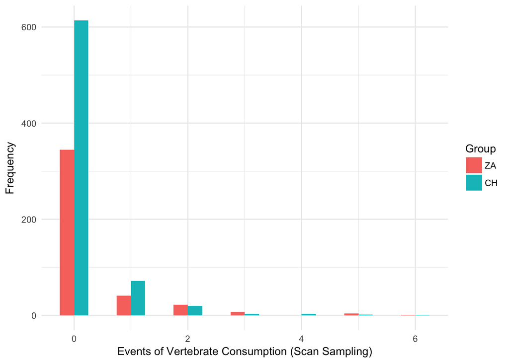

```r
ggplot(SSdata, aes(Scan.consumed.month, fill = Group)) +
    geom_histogram(binwidth=.5, position="dodge") +
    labs(x = 'Events of Vertebrate Consumption (Scan Sampling)', y = 'Frequency') +
    theme_minimal()
```

#### Differences of vertebrate consumption (from SS data) amongst Sex

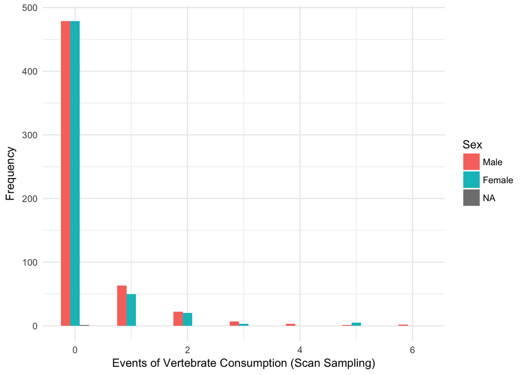

```r
ggplot(SSdata, aes(Scan.consumed.month, fill = Sex)) +
    geom_histogram(binwidth=.5, position="dodge") +
    labs(x = 'Events of Vertebrate Consumption (Scan Sampling)', y = 'Frequency') +
    theme_minimal()
```

#### Differences of vertebrate consumption (from SS data) amongst Seasons

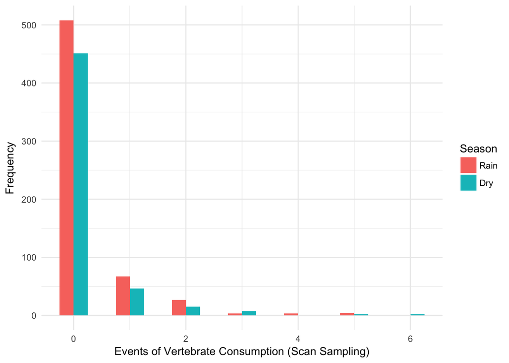

```r
ggplot(SSdata, aes(Scan.consumed.month, fill = Season)) +
    geom_histogram(binwidth=.5, position="dodge") +
    labs(x = 'Events of Vertebrate Consumption (Scan Sampling)', y = 'Frequency') +
    theme_minimal()
```

#### Differences of vertebrate consumption (from SS data) amongst Age groups

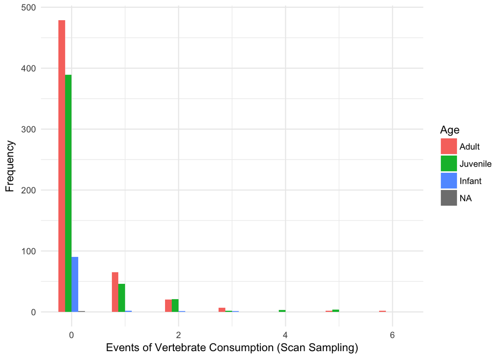

```r
ggplot(SSdata, aes(Scan.consumed.month, fill = Age)) +
    geom_histogram(binwidth=.5, position="dodge") +
    labs(x = 'Events of Vertebrate Consumption (Scan Sampling)', y = 'Frequency') +
    theme_minimal()
```

## Statisticall modelling

**Does seasonality influence insect availability?**

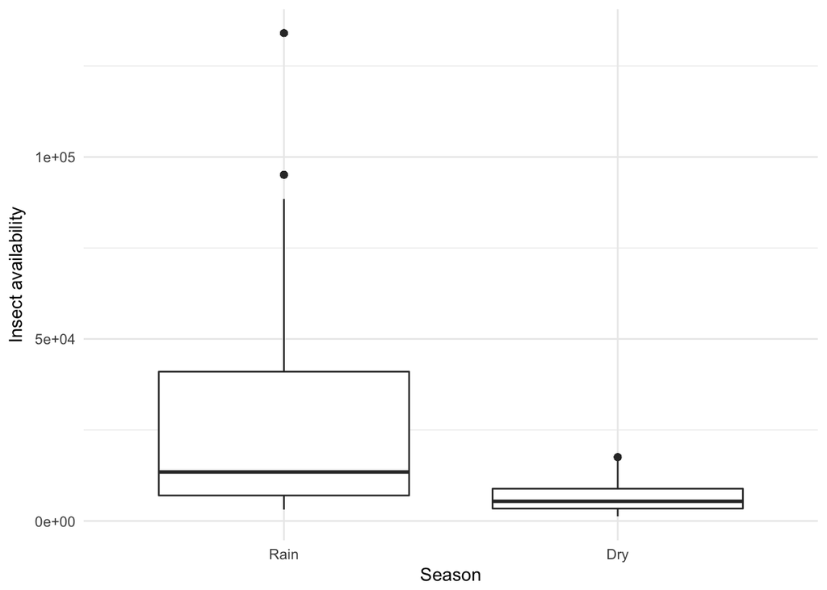

```r
ggplot(data = SSdata, aes(x = Season, y = Insect.availability)) +
    geom_boxplot() +
    labs(x = 'Season', y = 'Insect availability') +
    theme_minimal()
```

```r
## Formula interface
t.test(Insect.availability ~ Season, data = SSdata)
```

```
##
##  Welch Two Sample t-test
##
## data:  Insect.availability by Season
## t = 17.931, df = 604.47, p-value < 2.2e-16
## alternative hypothesis: true difference in means is not equal to 0
## 95 percent confidence interval:
##  22057.64 27483.54
## sample estimates:
## mean in group Rain  mean in group Dry
##          31243.283           6472.694
```

Yes! Highly significant (p-value ~ 0)

**Does seasonality influence fruit availability?**

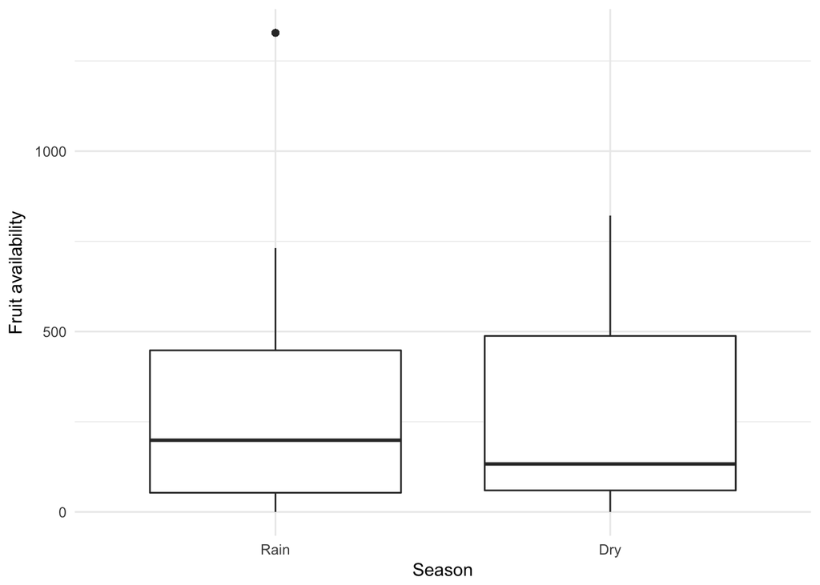

```r
ggplot(data = SSdata, aes(x = Season, y = Fruit.availability)) +
    geom_boxplot() +
    labs(x = 'Season', y = 'Fruit availability') +
    theme_minimal()
```

```r
## Formula interface
t.test(Fruit.availability ~ Season, data = SSdata)
```

```
##
##  Welch Two Sample t-test
##
## data:  Fruit.availability by Season
## t = 0.7363, df = 1100.9, p-value = 0.4617
## alternative hypothesis: true difference in means is not equal to 0
## 95 percent confidence interval:
##  -21.27881  46.84140
## sample estimates:
## mean in group Rain  mean in group Dry
##           293.1130           280.3317
```

Not really, (p-value = 0.4617)

**GENERAL ANALYSIS**, using all vertebrate data

```r
fit.nb.all <- glm.nb(Scan.consumed.month ~ Group + Season + Sex + Age + Insect.availability + Fruit.availability, data = SSdata) # This function has an extra parameter Theta, which corrects for bias caused by Poisson Regression assumption.

summary(fit.nb.all) # Negative Binomial Regression
```

```
##
## Call:
## glm.nb(formula = Scan.consumed.month ~ Group + Season + Sex +
##     Age + Insect.availability + Fruit.availability, data = SSdata,
##     init.theta = 0.2926377688, link = log)
##
## Deviance Residuals:
##     Min       1Q   Median       3Q      Max
## -0.8860  -0.6362  -0.5537  -0.4111   2.6763
##
## Coefficients:
##                       Estimate Std. Error z value Pr(>|z|)
## (Intercept)         -1.533e-01  2.663e-01  -0.576 0.564909
## GroupCH             -6.013e-01  1.783e-01  -3.373 0.000745 ***
## SeasonDry           -4.505e-01  1.922e-01  -2.344 0.019069 *
## SexFemale           -3.100e-01  1.775e-01  -1.746 0.080786 .
## AgeJuvenile         -1.232e-01  1.804e-01  -0.683 0.494705
## AgeInfant           -1.404e+00  4.559e-01  -3.079 0.002077 **
## Insect.availability -6.202e-06  3.593e-06  -1.726 0.084348 .
## Fruit.availability  -1.125e-03  3.334e-04  -3.375 0.000739 ***
## ---
## Signif. codes:  0 '***' 0.001 '**' 0.01 '*' 0.05 '.' 0.1 ' ' 1
##
## (Dispersion parameter for Negative Binomial(0.2926) family taken to be 1)
##
##     Null deviance: 542.47  on 1075  degrees of freedom
## Residual deviance: 504.63  on 1068  degrees of freedom
##   (59 observations deleted due to missingness)
## AIC: 1271.9
##
## Number of Fisher Scoring iterations: 1
##
##
##               Theta:  0.2926
##           Std. Err.:  0.0486
##
##  2 x log-likelihood:  -1253.8500
```

```r
est <- cbind(Estimate = coef(fit.nb.all), confint(fit.nb.all))
kable(exp(est)) # incident rate
```

|  | Estimate | 2.5 % | 97.5 % |
| --- | --- | --- | --- |
| (Intercept) | 0.8578895 | 0.5005191 | 1.4899437 |
| GroupCH | 0.5480843 | 0.3816622 | 0.7836931 |
| SeasonDry | 0.6372946 | 0.4324135 | 0.9353962 |
| SexFemale | 0.7334468 | 0.5141021 | 1.0429676 |
| AgeJuvenile | 0.8840895 | 0.6203182 | 1.2576294 |
| AgeInfant | 0.2456912 | 0.0946468 | 0.5625680 |
| Insect.availability | 0.9999938 | 0.9999864 | 1.0000010 |
| Fruit.availability | 0.9988754 | 0.9981938 | 0.9995338 |

When looking at the consumption of vertebrates (not discriminating any data) the variable that seems to have the greatest impact is the **availability of fruit**, and as fruit availability increases, vertebrate consumption tends to decrease. There was also a highly significant statistical difference amongst the two groups (provisioned and non-provisioned) with **CH** incident rate being only 54.81% of **ZA**. Infants also differ significantly from adults (p-value = 0.002) with an average incident rate of 24.56%, while juveniles did not differ significantly from adults (62.03-125.76% incident rate for the reference factor - adults). Season also impacts consumption (Dry < Wet) significantly. Sex and Insect availability do not have a significant impact for estimating vertebrate consumed count.

**Reptiles** (Lizards and Snakes)

```r
SSdata$REPTILES <- SSdata$Lizards + SSdata$Serpents
fit.nb <- glm.nb(REPTILES ~ Group + Season + Sex + Age + Insect.availability + Fruit.availability, data = SSdata)

summary(fit.nb) # Negative Binomial Regression
```

```
##
## Call:
## glm.nb(formula = REPTILES ~ Group + Season + Sex + Age + Insect.availability +
##     Fruit.availability, data = SSdata, init.theta = 0.181300056,
##     link = log)
##
## Deviance Residuals:
##     Min       1Q   Median       3Q      Max
## -0.5720  -0.4726  -0.4006  -0.3597   2.7545
##
## Coefficients:
##                       Estimate Std. Error z value Pr(>|z|)
## (Intercept)         -1.324e+00  3.617e-01  -3.659 0.000253 ***
## GroupCH             -7.219e-01  2.364e-01  -3.054 0.002261 **
## SeasonDry           -1.874e-01  2.592e-01  -0.723 0.469712
## SexFemale            1.486e-02  2.372e-01   0.063 0.950040
## AgeJuvenile         -2.767e-01  2.446e-01  -1.131 0.257938
## AgeInfant           -1.043e+00  5.442e-01  -1.917 0.055279 .
## Insect.availability -2.756e-06  4.841e-06  -0.569 0.569149
## Fruit.availability  -1.859e-04  4.038e-04  -0.460 0.645226
## ---
## Signif. codes:  0 '***' 0.001 '**' 0.01 '*' 0.05 '.' 0.1 ' ' 1
##
## (Dispersion parameter for Negative Binomial(0.1813) family taken to be 1)
##
##     Null deviance: 341.21  on 1075  degrees of freedom
## Residual deviance: 327.18  on 1068  degrees of freedom
##   (59 observations deleted due to missingness)
## AIC: 807.23
##
## Number of Fisher Scoring iterations: 1
##
##
##               Theta:  0.1813
##           Std. Err.:  0.0421
##
##  2 x log-likelihood:  -789.2300
```

```r
est <- cbind(Estimate = coef(fit.nb), confint(fit.nb))
kable(exp(est)) # incident rate
```

|  | Estimate | 2.5 % | 97.5 % |
| --- | --- | --- | --- |
| (Intercept) | 0.2661455 | 0.1275985 | 0.5597748 |
| GroupCH | 0.4858345 | 0.3001921 | 0.7806405 |
| SeasonDry | 0.8291021 | 0.4975606 | 1.3794899 |
| SexFemale | 1.0149703 | 0.6287586 | 1.6338565 |
| AgeJuvenile | 0.7582478 | 0.4656992 | 1.2268218 |
| AgeInfant | 0.3523433 | 0.1095094 | 0.9608002 |
| Insect.availability | 0.9999972 | 0.9999870 | 1.0000071 |
| Fruit.availability | 0.9998141 | 0.9989380 | 1.0006727 |

When looking specifically at lizards and snakes consumption count, the only variable with statistical significant differences is group, p-value = 0.002. CH incident rate is only 48.58% (30.02-78.06%, for a 95% Confidence Interval) of ZA incident rate. Interestingly females ate more reptiles than male (not significant, though).

CH < ZA

**Mammals** (Rodents, Marsupials, Bats and other mammals)

```r
SSdata$MAMMALS <- SSdata$Rodents + SSdata$MarsupialsMammals + SSdata$Chiroptera
fit.nb <- glm.nb(MAMMALS ~ Group + Season + Sex + Age + Insect.availability + Fruit.availability, data = SSdata)

summary(fit.nb) # Negative Binomial Regression
```

```
##
## Call:
## glm.nb(formula = MAMMALS ~ Group + Season + Sex + Age + Insect.availability +
##     Fruit.availability, data = SSdata, init.theta = 0.09723121523,
##     link = log)
##
## Deviance Residuals:
##     Min       1Q   Median       3Q      Max
## -0.6316  -0.3792  -0.2730  -0.1613   2.4367
##
## Coefficients:
##                       Estimate Std. Error z value Pr(>|z|)
## (Intercept)         -4.204e-01  4.966e-01  -0.847  0.39721
## GroupCH             -4.469e-01  3.425e-01  -1.305  0.19191
## SeasonDry           -8.656e-01  3.645e-01  -2.375  0.01757 *
## SexFemale           -9.617e-01  3.451e-01  -2.787  0.00532 **
## AgeJuvenile          7.245e-02  3.400e-01   0.213  0.83126
## AgeInfant           -1.574e+00  9.184e-01  -1.714  0.08656 .
## Insect.availability -1.130e-05  6.578e-06  -1.717  0.08589 .
## Fruit.availability  -4.207e-03  9.393e-04  -4.479  7.5e-06 ***
## ---
## Signif. codes:  0 '***' 0.001 '**' 0.01 '*' 0.05 '.' 0.1 ' ' 1
##
## (Dispersion parameter for Negative Binomial(0.0972) family taken to be 1)
##
##     Null deviance: 225.68  on 1075  degrees of freedom
## Residual deviance: 180.97  on 1068  degrees of freedom
##   (59 observations deleted due to missingness)
## AIC: 516.93
##
## Number of Fisher Scoring iterations: 1
##
##
##               Theta:  0.0972
##           Std. Err.:  0.0248
##
##  2 x log-likelihood:  -498.9330
```

```r
est <- cbind(Estimate = coef(fit.nb), confint(fit.nb))
kable(exp(est)) # incident rate
```

|  | Estimate | 2.5 % | 97.5 % |
| --- | --- | --- | --- |
| (Intercept) | 0.6567887 | 0.2252042 | 2.0698882 |
| GroupCH | 0.6395877 | 0.3059671 | 1.3218933 |
| SeasonDry | 0.4207865 | 0.1838335 | 0.9265882 |
| SexFemale | 0.3822266 | 0.1911331 | 0.7433396 |
| AgeJuvenile | 1.0751349 | 0.5497938 | 2.0952091 |
| AgeInfant | 0.2071989 | 0.0277407 | 0.9959297 |
| Insect.availability | 0.9999887 | 0.9999749 | 1.0000015 |
| Fruit.availability | 0.9958019 | 0.9938945 | 0.9974562 |

**Birds**

```r
fit.nb <- glm.nb(Aves ~ Group + Season + Sex + Age + Insect.availability + Fruit.availability, data = SSdata_without_infants)

summary(fit.nb) # Negative Binomial Regression
```

```
##
## Call:
## glm.nb(formula = Aves ~ Group + Season + Sex + Age + Insect.availability +
##     Fruit.availability, data = SSdata_without_infants, init.theta = 0.0270323152,
##     link = log)
##
## Deviance Residuals:
##     Min       1Q   Median       3Q      Max
## -0.3441  -0.2285  -0.1821  -0.1360   2.6529
##
## Coefficients:
##                       Estimate Std. Error z value Pr(>|z|)
## (Intercept)         -1.478e+00  8.602e-01  -1.719   0.0857 .
## GroupCH             -2.869e-01  6.063e-01  -0.473   0.6360
## SeasonDry           -1.551e+00  6.531e-01  -2.375   0.0175 *
## SexFemale           -8.946e-01  5.937e-01  -1.507   0.1319
## AgeJuvenile         -3.401e-01  5.890e-01  -0.577   0.5637
## Insect.availability -1.017e-05  1.096e-05  -0.928   0.3536
## Fruit.availability  -1.819e-03  1.173e-03  -1.551   0.1209
## ---
## Signif. codes:  0 '***' 0.001 '**' 0.01 '*' 0.05 '.' 0.1 ' ' 1
##
## (Dispersion parameter for Negative Binomial(0.027) family taken to be 1)
##
##     Null deviance: 77.903  on 982  degrees of freedom
## Residual deviance: 67.678  on 976  degrees of freedom
##   (58 observations deleted due to missingness)
## AIC: 240.61
##
## Number of Fisher Scoring iterations: 1
##
##
##               Theta:  0.0270
##           Std. Err.:  0.0106
##
##  2 x log-likelihood:  -224.6070
```

```r
est <- cbind(Estimate = coef(fit.nb), confint(fit.nb))
kable(exp(est)) # incident rate
```

|  | Estimate | 2.5 % | 97.5 % |
| --- | --- | --- | --- |
| (Intercept) | 0.2280462 | 0.0445307 | 1.6145819 |
| GroupCH | 0.7505569 | 0.1837845 | 2.9060039 |
| SeasonDry | 0.2119686 | 0.0531632 | 0.7540215 |
| SexFemale | 0.4087592 | 0.0995628 | 1.5149580 |
| AgeJuvenile | 0.7117008 | 0.2098094 | 2.3091576 |
| Insect.availability | 0.9999898 | 0.9999645 | 1.0000144 |
| Fruit.availability | 0.9981827 | 0.9954583 | 1.0005063 |

When looking at birds, only season is significant (p-value = 0.0175), Dry < Wet, with Dry incident rate as 21.19% of Wet incident rate.

**note**: there are 0 instances of infants eating birds, so they were not considered in this last model (notice in formula)